*Reading this on GitHub? [Check out the README in this folder (`/notebooks`)](https://github.com/StatCan/hackathon-ginyu-force-data/tree/main/notebooks#running-these-notebooks-on-aaw) for instructions on how to run this notebook using the Advanced Analytics Workspace!*

# ESTMA Payments by Country and Entity

Let's do some R analysis to gain some insights into the Open ESTMA Data.

Specifically, let's analyze the overall amount paid broken down by country and by different percentiles of entities. This will give us a sense of how much contribution comes from where.

# Get the data

Grab the data straight from GitHub.

Mutate the tables to adjust the column types. We're going to fix the date formats and make the amount_reported column numeric

Display a sample record.

```
'data.frame':	1 obs. of  13 variables:
 $ estma_id           : chr "E001568"
 $ entity             : chr "Rochester Resources Ltd."
 $ jurisdiction       : chr "Canada"
 $ period_start_date  : Date, format: NA
 $ period_end_date    : Date, format: NA
 $ country            : chr "Mexico"
 $ payee_project_name : chr "GENERAL MINING DIRECTION OF THE SECRETARIAT OF ECONOMY"
 $ payee_or_project   : chr "payee"
 $ payment_category   : chr "Fees"
 $ amount_reported_cad: num 217444
 $ type_of_report     : chr "Individual Report"
 $ reporting_cycle    : int 2016
 $ web_link           : chr "https://www.dropbox.com/s/qh3p9uj615ryv4u/RCT - 2017.xlsx?dl=0"
```

## Amount reported by country

We're going to group-by country, and to make the display render nicely, we also cut off countries who fall underneath of the bottom 3% of the range of amount reported. (Note: this is not the bottom 3%, it's the bottom 80% of countries in fact. It's a huge number who gets removed, but their contributions are tiny)

```
Total countries: 133
Countries above 3.0% of range: 27
```

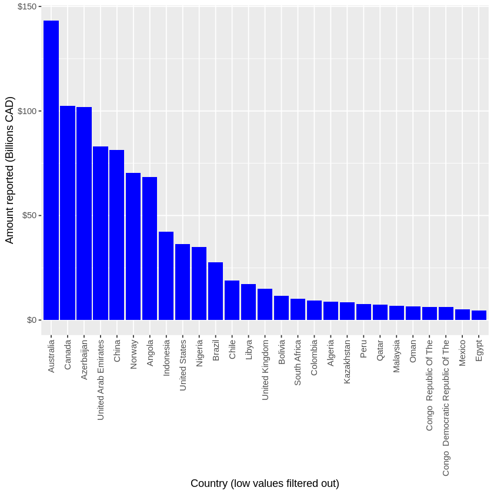

## Large entities

Now lets turn to entities. We'll group by entity and plot the distribution as above

```
Number of entities: 695
```

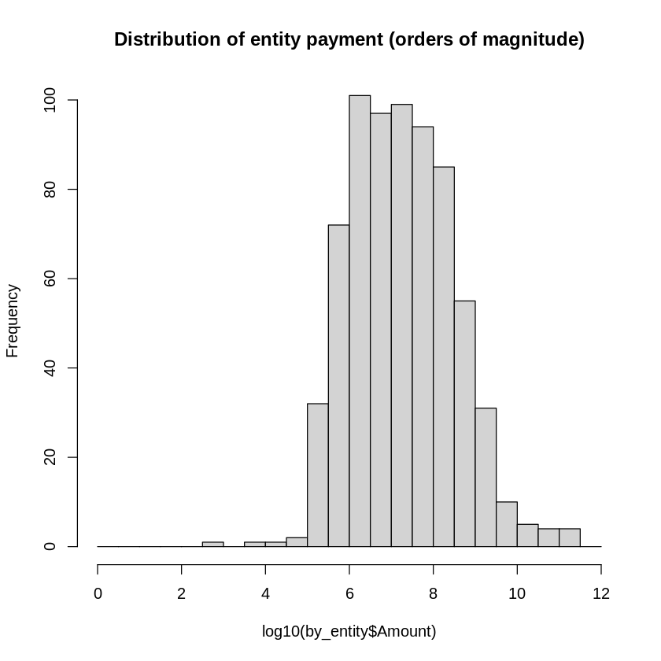

How much is contributed to the total amount per quantile? Lets group the entities into percentiles

### How much does each quantile contribute in terms of total share?

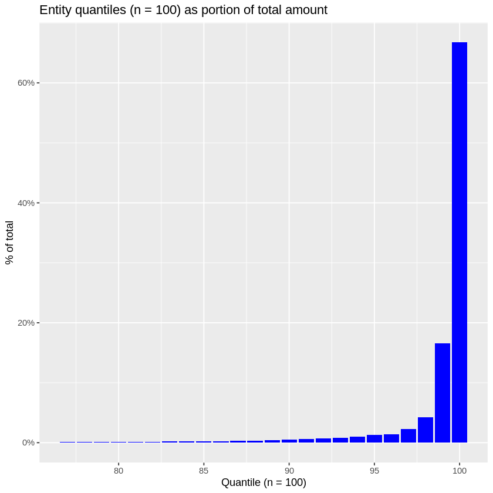

We can plot this horizontally in order to see visually how the different percentiles add up to the total share contributed.

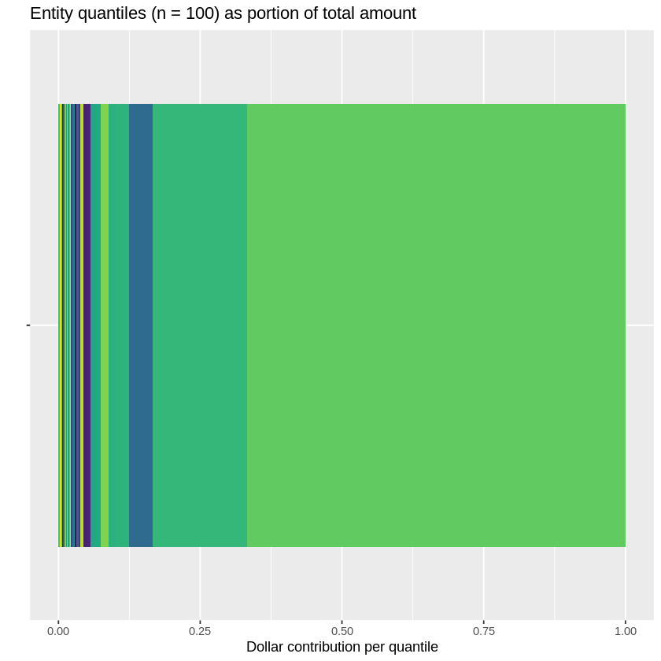

As you can see, the top 1% of entities account for more than 60% of the total amount paid.

### Greatest total payments

We can also see this just by looking at the top 10 entities, the amounts drop-off very quickly

A tibble: 10 × 2

| entity <chr> | Amount <chr> |
| --- | --- |
| Bp Canada Energy Group Ulc | 157.9 B |
| Total E&P Canada Ltd. | 156.3 B |
| Cnooc Limited | 108.1 B |
| Equinor Canada Ltd. | 104.7 B |
| Bhp Canada Inc. | 90.5 B |
| Rio Tinto Canada Inc | 50.9 B |
| Chevron Canada Limited | 45.4 B |
| Azucar Minerals Ltd. | 36.1 B |
| Glencore Canada Corporation | 30.5 B |
| Repsol Oil & Gas Canada Inc. | 23.9 B |